# Competição Titanic Machine Learning

Aprendizado de Máquina com Desastres

Uallas Leles

Início: Abril de 2020 | Atualização: 19/junho/2021

Diretório de Trabalho:

```
[1] "C:/Users/ulp/Dropbox/GitHub/R/Titanic"
```

# 1 Dependências

## 1.1 Pacotes

```r
source(file = "scripts/packages_require.R")
```

[output not shown]

## 1.2 Funções

```r
source(file = "scripts/functions.R")
```

# 2 Definição do Problema

> **Definição**

*O naufrágio do Titantic resultou na morte de 1502 dos 2224 passageiros e tripulantes.*

*Embora houvesse algum elemento de sorte envolvido na sobrevivência, parece que alguns grupos de pessoas eram mais propensos a sobreviver do que outros.*

*Construa um modelo preditivo que responda à pergunta:* *“Que tipo de pessoas têm maior probabilidade de sobreviver?”.*

> **Dataset**

*Dois conjuntos de dados semelhantes, que incluem informações sobre passageiros como nome, idade, sexo, classe socioeconômica, etc.*

*Um conjunto de dados é intitulado “train.csv” e o outro é intitulado “test.csv”.*

- *O Train.csv conterá os detalhes de um subconjunto dos passageiros a bordo (891) e, mais importante, revelará se eles sobreviveram ou não, também conhecida como “verdade do solo”.*
- *O Test.csv contém informações semelhantes, mas não divulga a “verdade básica” para cada passageiro. É seu trabalho prever esses resultados.*

> **Link**
- [Kaggle: Titanic.](https://www.kaggle.com/c/titanic/data)

> **Objetivo**

*Usando os padrões encontrados nos dados train.csv,* *preveja se os outros 418 passageiros a bordo (encontrados em test.csv) sobreviveram.*

# 3 Planejamento

1. *Coleta de dados com StringAsFactor como false.*
2. *Combinar os conjuntos de treino e teste.*
3. *Limpeza e transformação das variáveis.*
4. *Dividir os conjuntos novamente.*
5. *Fazer a Análise Exploratória do conjunto de treino.*

# 4 Coleta

## 4.1 Extração

```r
source(file = "scripts/ds_load.R")
```

```r
source(file = "scripts/unindo_datasets.R")
```

### 4.1.1 Pré-visualização dos Dados

```r
# TREINO: Pré-visualização das primeiras observações:
etl.full %>%
    head() %>%
    tibble(format = "markdown", caption = "Primeiras observações")
```

| PassengerId | Pclass | Name | Sex | Age | SibSp | Parch | Ticket | Fare | Cabin | Embarked | idx | format | caption |
| --- | --- | --- | --- | --- | --- | --- | --- | --- | --- | --- | --- | --- | --- |
| 1 | 3 | Braund, Mr. Owen Harris | male | 22 | 1 | 0 | A/5 21171 | 7,2500 |  | S | treino | markdown | Primeiras observações |
| 2 | 1 | Cumings, Mrs. John Bradley (Florence Briggs Thayer) | female | 38 | 1 | 0 | PC 17599 | 71,2833 | C85 | C | treino | markdown | Primeiras observações |
| 3 | 3 | Heikkinen, Miss. Laina | female | 26 | 0 | 0 | STON/O2. 3101282 | 7,9250 |  | S | treino | markdown | Primeiras observações |
| 4 | 1 | Futrelle, Mrs. Jacques Heath (Lily May Peel) | female | 35 | 1 | 0 | 113803 | 53,1000 | C123 | S | treino | markdown | Primeiras observações |
| 5 | 3 | Allen, Mr. William Henry | male | 35 | 0 | 0 | 373450 | 8,0500 |  | S | treino | markdown | Primeiras observações |
| 6 | 3 | Moran, Mr. James | male | NA | 0 | 0 | 330877 | 8,4583 |  | Q | treino | markdown | Primeiras observações |

```r
print(etl.full)
```

| PassengerId | Pclass | Name | Sex | Age | SibSp | Parch | Ticket | Fare | Cabin | Embarked | idx |
| --- | --- | --- | --- | --- | --- | --- | --- | --- | --- | --- | --- |
| 1 | 3 | Braund, Mr. Owen Harris | male | 22,00 | 1 | 0 | A/5 21171 | 7,2500 |  | S | treino |
| 2 | 1 | Cumings, Mrs. John Bradley (Florence Briggs Thayer) | female | 38,00 | 1 | 0 | PC 17599 | 71,2833 | C85 | C | treino |
| 3 | 3 | Heikkinen, Miss. Laina | female | 26,00 | 0 | 0 | STON/O2. 3101282 | 7,9250 |  | S | treino |
| 4 | 1 | Futrelle, Mrs. Jacques Heath (Lily May Peel) | female | 35,00 | 1 | 0 | 113803 | 53,1000 | C123 | S | treino |
| 5 | 3 | Allen, Mr. William Henry | male | 35,00 | 0 | 0 | 373450 | 8,0500 |  | S | treino |
| 6 | 3 | Moran, Mr. James | male | NA | 0 | 0 | 330877 | 8,4583 |  | Q | treino |
| 7 | 1 | McCarthy, Mr. Timothy J | male | 54,00 | 0 | 0 | 17463 | 51,8625 | E46 | S | treino |
| 8 | 3 | Palsson, Master. Gosta Leonard | male | 2,00 | 3 | 1 | 349909 | 21,0750 |  | S | treino |
| 9 | 3 | Johnson, Mrs. Oscar W (Elisabeth Vilhelmina Berg) | female | 27,00 | 0 | 2 | 347742 | 11,1333 |  | S | treino |
| 10 | 2 | Nasser, Mrs. Nicholas (Adele Achem) | female | 14,00 | 1 | 0 | 237736 | 30,0708 |  | C | treino |

[output cut: 990 more lines]

## 4.2 Resumo da Importação

### 4.2.1 Dimensões

```r
dim(treino) # Dimensões do dataset de treino
```

```
[1] 891  12
```

```r
dim(teste)  # Dimensões do dataset de teste
```

```
[1] 418  11
```

### 4.2.2 Estrutura

```r
str(titanic) # Estrutura do dataset
```

```
'data.frame':   1309 obs. of  12 variables:
 $ PassengerId: int  1 2 3 4 5 6 7 8 9 10 ...
 $ Pclass     : int  3 1 3 1 3 3 1 3 3 2 ...
 $ Name       : chr  "Braund, Mr. Owen Harris" "Cumings, Mrs. John Bradley (Florence Briggs Thayer)" "Heikkinen, Miss. Laina" "Futrelle, Mrs. Jacques Heath (Lily May Peel)" ...
 $ Sex        : chr  "male" "female" "female" "female" ...
 $ Age        : num  22 38 26 35 35 NA 54 2 27 14 ...
 $ SibSp      : int  1 1 0 1 0 0 0 3 0 1 ...
 $ Parch      : int  0 0 0 0 0 0 0 1 2 0 ...
 $ Ticket     : chr  "A/5 21171" "PC 17599" "STON/O2. 3101282" "113803" ...
 $ Fare       : num  7,25 71,28 7,92 53,1 8,05 ...
 $ Cabin      : chr  "" "C85" "" "C123" ...
 $ Embarked   : chr  "S" "C" "S" "S" ...
 $ idx        : Factor w/ 2 levels "treino","teste": 1 1 1 1 1 1 1 1 1 1 ...
```

## 4.3 Dicionário de Atributos

```r
# 1    PassengerId: ID
# 2       Survived: Sobrevivência
#                   - 0 = Não
#                   - 1 = Sim
# 3         Pclass: Classe de ingresso | 1 = 1ª, 2 = 2ª, 3 = 3ª
#                   - Uma proxy para o status socioeconômico (SES)
#                   1st = Upper
#                   2nd = Middle
#                   3rd = Lower
# 4           Name: Nome
# 5            Sex: Sexo
# 6            Age: Idade em anos
#                   - A idade é fracionária se menor que 1.
#                   - Se a idade é estimada, está na forma de xx.5
# 7          SibSp: Nº de irmãos / Cônjuges a bordo do Titanic
#                   - O conjunto de dados define as relações familiares
#                     dessa maneira:
#                   Sibling =
#                       - irmão
#                       - irmã
#                       - meio-irmão
#                       - meia-irmã
#                   Spouse =
#                       - marido
#                       - esposa
#                       - (amantes e noivos foram ignorados)
# 8          Parch: Nº de pais / filhos a bordo do Titanic
#                   - O conjunto de dados define as relações familiares
#                     dessa maneira:
#                   Parent =
#                       - mãe
#                       - pai
#                   Child =
#                       - filha
#                       - filho
#                       - enteada
#                       - enteado
#                       Algumas crianças viajavam apenas com uma babá,
#                       portanto:
#                       - Parch = 0 para elas.
# 9         Ticket: Número do bilhete
# 10          Fare: Tarifa de passageiro
# 11         Cabin: Número da cabine
# 12      Embarked: Porto de embarcação
#                   - C = Cherbourg
#                   - Q = Queenstown
#                   - S = Southampton
```

## 4.4 Limpeza e Transformação

Esta etapa corresponde a um pré-processamento para então iniciar a análise exploratória de dados.

### 4.4.1 Dados Faltantes

```r
# Soma de valores missing por variável em Treino
if(any(is.na(etl.full)))
  {
    subset(data.frame("SubTotal_NA" = apply(etl.full,
                                     2,
                                     function(x){
                                       sum(is.na(x))
                                       })), SubTotal_NA > 0)
}
```

|  | SubTotal_NA |
| --- | --- |
| Age | 263 |
| Fare | 1 |

```r
# missmap(etl.full)
```

### 4.4.2 Imputação de Dados

```r
imp <- mice(etl.full, method='rf')
```

```
Number of logged events: 5
```

```r
imp_out <- complete(imp)
etl.full$Age <- imp_out$Age
etl.full$Fare <- imp_out$Fare
```

### 4.4.3 Transformando para Fator

```r
# Variável 'Survived'
etl.trn$Survived <- factor(etl.trn$Survived, labels = c("Não", "Sim"))
```

```r
# Variável 'Pclass'
etl.full$Pclass <- factor(etl.full$Pclass, labels = c("1ª classe", "2ª classe", "3ª classe"), ordered = TRUE)
```

```r
# Variável 'Sex'
etl.full$Sex <- factor(etl.full$Sex, labels = c(male = "Homem", female = "Mulher"))
```

```r
# Variável 'Embarked'
etl.full$Embarked <- factor(etl.full$Embarked, labels = c(" " = " - ", C = "Cherbourg", Q = "Queenstown", S = "Southampton"))
```

### 4.4.4 Separando os Datasets

```r
# Retornando os dados para os datasets originais
etl.trn[,colnames(etl.full)] <- subset(etl.full, etl.full$idx == 'treino')
etl.tst[,colnames(etl.full)]  <- subset(etl.full, etl.full$idx == 'teste')
```

### 4.4.5 Removendo Variáveis

```r
# Removendo variável 'PassengerId'
etl.full$PassengerId <- NULL
etl.trn$PassengerId <- NULL
etl.tst$PassengerId <- NULL
# Removendo variável 'PassengerId'
etl.full$Name <- NULL
etl.trn$Name <- NULL
etl.tst$Name <- NULL
# Removendo a variável 'flag'
etl.full$Cabin <- NULL
etl.trn$Cabin <- NULL
etl.tst$Cabin <- NULL
# Removendo a variável 'flag'
etl.full$idx <- NULL
etl.trn$idx <- NULL
etl.tst$idx <- NULL
```

### 4.4.6 Resultado da E.T.L.

```r
# write.csv(treino.etl, "../datasets/treino_etl.csv", row.names = FALSE)
dput(etl.trn, file = "datasets/etl_trn.R")
dput(etl.tst, file = "datasets/etl_tst.R")
dput(etl.full, file = "datasets/etl_full.R")
```

# 5 Análise Exploratória

A ideia de uma análise descritiva de dados é tentar responder as seguintes questões:

1. Qual a *frequência* com que cada valor (ou intervalo de valores) aparece no conjunto de dados. Ou seja, qual a distribuição de frequências dos dados?
2. Quais são alguns *valores típicos* do conjunto de dados, como mínimo e máximo?
3. Qual seria um valor para representar a *posição central* do conjunto de dados?
4. Qual seria uma medida da *variabilidade* ou dispersão dos dados?
5. Existem *valores atípicos* ou discrepantes (outliers) no conjunto de dados?
6. Os dados são simétricos? Qual a *simetria* dos dados?

```r
aed.trn <- dget(file = "datasets/etl_trn.R")
```

## 5.1 Classificando as Variáveis

Uma boa forma de iniciar uma análise descritiva adequada é verificar os tipos de variáveis disponíveis.

```r
# Qualitativas Nominais
var.fct <- c()
for(i in 1:ncol(aed.trn)){
    if(is.factor(aed.trn[,i]) && !is.ordered(aed.trn[,i]))
    {
        var.fct = c(var.fct, names(aed.trn)[i])
    }
}
# Qualitativas Ordinais
var.fct_ord <- c()
for(i in 1:ncol(aed.trn)){
  i = 1
    if(is.factor(aed.trn[,i]) && is.ordered(aed.trn[,i]))
    {
        var.fct_ord = c(var.fct_ord, names(aed.trn)[i])
    }
}
# Quantitativas Contínuas
var.num_con <- c()
for(i in 1:ncol(aed.trn)){
    if(typeof(aed.trn[,i]) == "double")
    {
        var.num_con <- c(var.num_con, names(aed.trn)[i])
    }
}
data.frame("Qualitativas_Nominais - " = var.fct)
```

| Qualitativas_Nominais... |
| --- |
| Survived |
| Sex |
| Embarked |

```r
data.frame("Qualitativas_Ordinais - " = var.fct_ord)
```

```r
data.frame("Quantitativas_Discretas - " = var.num)
```

| Quantitativas_Discretas... |
| --- |
| SibSp |
| Parch |

```r
data.frame("Quantitativas_Contínuas - " = var.num_con)
```

| Quantitativas_Contínuas... |
| --- |
| Age |
| Fare |

## 5.2 Análise Univariada

```r
describe(aed.trn )
```

|  | vars | n | mean | sd | median | trimmed | mad | min | max | range | skew | kurtosis | se |
| --- | --- | --- | --- | --- | --- | --- | --- | --- | --- | --- | --- | --- | --- |
| Survived* | 1 | 891 | 1,38 | 0,49 | 1,00 | 1,35 | 0,00 | 1,00 | 2,00 | 1,00 | 0,48 | -1,77 | 0,02 |
| Pclass* | 2 | 891 | 2,31 | 0,84 | 3,00 | 2,39 | 0,00 | 1,00 | 3,00 | 2,00 | -0,63 | -1,28 | 0,03 |
| Sex* | 3 | 891 | 1,65 | 0,48 | 2,00 | 1,68 | 0,00 | 1,00 | 2,00 | 1,00 | -0,62 | -1,62 | 0,02 |
| Age | 4 | 891 | 29,52 | 14,28 | 28,00 | 28,97 | 11,86 | 0,42 | 80,00 | 79,58 | 0,46 | 0,30 | 0,48 |
| SibSp | 5 | 891 | 0,52 | 1,10 | 0,00 | 0,27 | 0,00 | 0,00 | 8,00 | 8,00 | 3,68 | 17,73 | 0,04 |
| Parch | 6 | 891 | 0,38 | 0,81 | 0,00 | 0,18 | 0,00 | 0,00 | 6,00 | 6,00 | 2,74 | 9,69 | 0,03 |
| Ticket* | 7 | 891 | 339,52 | 200,83 | 338,00 | 339,65 | 268,35 | 1,00 | 681,00 | 680,00 | 0,00 | -1,28 | 6,73 |
| Fare | 8 | 891 | 32,20 | 49,69 | 14,45 | 21,38 | 10,24 | 0,00 | 512,33 | 512,33 | 4,77 | 33,12 | 1,66 |
| Embarked* | 9 | 891 | 3,53 | 0,80 | 4,00 | 3,66 | 0,00 | 1,00 | 4,00 | 3,00 | -1,27 | -0,16 | 0,03 |

### 5.2.1 Distribuições de Frequências

A primeira tarefa de uma análise estatística de um conjunto de dados consiste em resumí-los. As técnicas disponíveis para essa finalidade dependem dos tipos de variáveis envolvidas.

#### 5.2.1.1 Variáveis Qualitativas

As distribuições podem ser representadas por meio de:

- Gráfico de Barras
- Gráfico do tipo Pizza
> 1. **Distribuições de Frequências para as Variáveis Qualitativas Nominais**

```r
# Distribuição de Frequências para as Variáveis Qualitativas Nominais
for(i in var.fct){
      fdt_cat(aed.trn[,i]) %>%
          tibble() -> df
    names(df)[1] = c(colnames(aed.trn[i]))
    print(kable(df[order(df[2], decreasing = TRUE),]))
}
```

| Survived | f | rf | rf(%) | cf | cf(%) |
| --- | --- | --- | --- | --- | --- |
| Não | 549 | 0,6161616 | 61,61616 | 549 | 61,61616 |
| Sim | 342 | 0,3838384 | 38,38384 | 891 | 100,00000 |

| Sex | f | rf | rf(%) | cf | cf(%) |
| --- | --- | --- | --- | --- | --- |
| Mulher | 577 | 0,647587 | 64,7587 | 577 | 64,7587 |
| Homem | 314 | 0,352413 | 35,2413 | 891 | 100,0000 |

| Embarked | f | rf | rf(%) | cf | cf(%) |
| --- | --- | --- | --- | --- | --- |
| Southampton | 644 | 0,7227834 | 72,2783389 | 644 | 72,27834 |
| Cherbourg | 168 | 0,1885522 | 18,8552189 | 812 | 91,13356 |
| Queenstown | 77 | 0,0864198 | 8,6419753 | 889 | 99,77553 |
| - | 2 | 0,0022447 | 0,2244669 | 891 | 100,00000 |

> 2. **Distribuições de Frequências para as Variáveis Qualitativas Ordinais**

```r
# Distribuição de Frequências para as Variáveis Qualitativas Ordinais
for(i in var.fct_ord){
      fdt_cat(aed.trn[,i]) %>%
          tibble() -> df
    names(df)[1] = c(colnames(aed.trn[i]))
    print(kable(df[order(df[2], decreasing = TRUE),]))
}
```

> 3. **Gráfico de Barras: Variáveis Qualitativas**

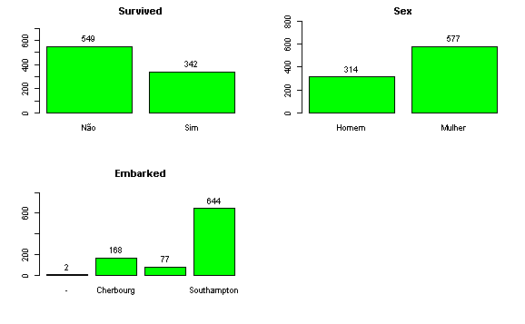

```r
# Gráficos de barras para variáveis categóricas
par(mfrow=c(2,2), cex = 0.55)
for(i in c(var.fct, var.fct_ord)){
        bp <- barplot(table(aed.trn[i]),
                      main = names(aed.trn[i]),
                      ylim = c(0, max(table(aed.trn[i]))*1.4),
                      col = "green")
        text(x = as.vector(bp),
            y = table(aed.trn[,i]) + 2,
            label =  round(table(aed.trn[i]), 1),
            pos = 3,
            col = "black")
}
```

#### 5.2.1.2 Variáveis Quantitativas

- Discretas
- Contínuas

  > Agrupam-se os valores das variáveis em classes e obtêm-se as frequências em cada classe.

As distribuições podem ser representadas por meio de:

- Gráfico de Dispersão Unidimensional (dotplot)
- Gráfico Ramo e Folhas (Steam and Leaf)
- Histograma
> 4. **Distribuição de Frequências: Variáveis Quantitativas**

```r
par(mfrow=c(2,1))
# Distribuição de Frequências: Variáveis Quantitativas
for(i in var.num_con){
        df <- fdt(aed.trn[,i])
        #names(df)[[1]] = c(colnames(aed.trn[i]))
        print(kable(df, caption = "Title of the table"))
}
```

Title of the table

| Class limits | f | rf | rf(%) | cf | cf(%) |
| --- | --- | --- | --- | --- | --- |
| [0,4158,7,723) | 58 | 0,0650954 | 6,5095398 | 58 | 6,50954 |
| [7,723,15,03) | 40 | 0,0448934 | 4,4893378 | 98 | 10,99888 |
| [15,03,22,34) | 196 | 0,2199776 | 21,9977553 | 294 | 32,99663 |
| [22,34,29,65) | 202 | 0,2267116 | 22,6711560 | 496 | 55,66779 |
| [29,65,36,95) | 161 | 0,1806958 | 18,0695847 | 657 | 73,73737 |
| [36,95,44,26) | 98 | 0,1099888 | 10,9988777 | 755 | 84,73625 |
| [44,26,51,57) | 67 | 0,0751964 | 7,5196409 | 822 | 92,25589 |
| [51,57,58,88) | 33 | 0,0370370 | 3,7037037 | 855 | 95,95960 |
| [58,88,66,18) | 27 | 0,0303030 | 3,0303030 | 882 | 98,98990 |
| [66,18,73,49) | 7 | 0,0078563 | 0,7856341 | 889 | 99,77553 |
| [73,49,80,8) | 2 | 0,0022447 | 0,2244669 | 891 | 100,00000 |

|  | x |
| --- | --- |
| start | 0,415800 |
| end | 80,800000 |
| h | 7,307654 |
| right | 0,000000 |

Title of the table

| Class limits | f | rf | rf(%) | cf | cf(%) |
| --- | --- | --- | --- | --- | --- |
| [0,47,0411) | 726 | 0,8148148 | 81,4814815 | 726 | 81,48148 |
| [47,0411,94,0823) | 112 | 0,1257015 | 12,5701459 | 838 | 94,05163 |
| [94,0823,141,123) | 22 | 0,0246914 | 2,4691358 | 860 | 96,52076 |
| [141,123,188,165) | 11 | 0,0123457 | 1,2345679 | 871 | 97,75533 |
| [188,165,235,206) | 9 | 0,0101010 | 1,0101010 | 880 | 98,76543 |
| [235,206,282,247) | 8 | 0,0089787 | 0,8978676 | 888 | 99,66330 |
| [282,247,329,288) | 0 | 0,0000000 | 0,0000000 | 888 | 99,66330 |
| [329,288,376,329) | 0 | 0,0000000 | 0,0000000 | 888 | 99,66330 |
| [376,329,423,37) | 0 | 0,0000000 | 0,0000000 | 888 | 99,66330 |
| [423,37,470,411) | 0 | 0,0000000 | 0,0000000 | 888 | 99,66330 |
| [470,411,517,452) | 3 | 0,0033670 | 0,3367003 | 891 | 100,00000 |

|  | x |
| --- | --- |
| start | 0,00000 |
| end | 517,45249 |
| h | 47,04114 |
| right | 0,00000 |

##### 5.2.1.2.1 Gráficos

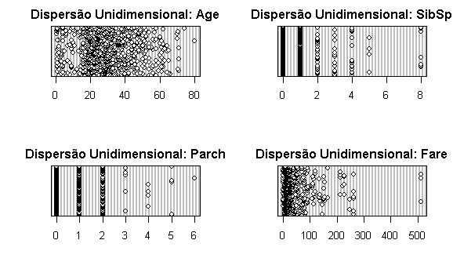

```r
par(mfrow=c(2,2))
# Gráfico de Dispersão Unidimensional: Variáveis Quantitativas
for(i in 1:ncol(aed.trn)){
    if(is.numeric(aed.trn[,i])){
        dotchart(aed.trn[,i], main = paste("Dispersão Unidimensional:", names(aed.trn)[i]))
    }
}
```

```r
# Gráfico Ramo e Folhas: Variáveis Quantitativas
for(i in 1:ncol(aed.trn)){
    if(is.numeric(aed.trn[,i])){
        stem(aed.trn[,i])
    }
}
```

```
  The decimal point is 1 digit(s) to the right of the |

  0 | 011111111111111122222222222223333334444444444444
  0 | 5555666777888899999999
  1 | 0000111122334444444
  1 | 55555555566666666666666666666666777777777777777888888888888888888888+27
  2 | 00000000000000000000000111111111111111111111111111111111112222222222+73
  2 | 55555555555555555555555555555556666666666666666666666677777777777777+67
  3 | 00000000000000000000000000000000111111111111111111111112222222222222+35
  3 | 55555555555555555556666666666666666666666666677777777888888888888889+4
  4 | 00000000000000000000111111111222222222222223333344444444444
  4 | 555555555555566666677777777777888888888889999999
  5 | 00000000000011111112222222344444444
  5 | 5556666667788888899
  6 | 000011111122222233444
```

[output cut: 56 more lines]

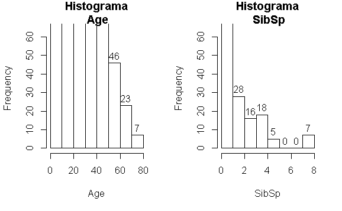

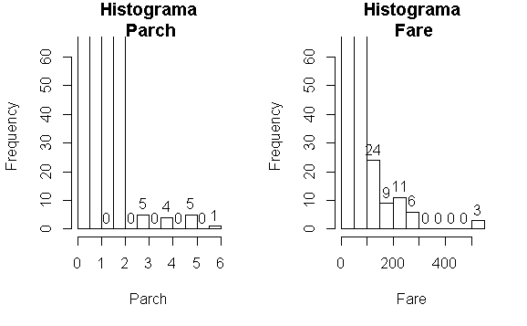

```r
# Gráfico Histograma: Varáveis Quantitativas
par(mfrow=c(1,2))
for(i in 1:ncol(aed.trn)){
    if(is.numeric(aed.trn[,i])){

        hist(aed.trn[,i],
             main = paste("Histograma\n", names(aed.trn)[i]),
             xlab = names(aed.trn)[i],
             ylim = c(0, max(table(aed.trn[,"Fare"]))*1.5),
             labels = TRUE,
             nclass = round(1+3.22*log10(nrow(as.array(aed.trn[,i])))) )
    }
}
```

### 5.2.2 Medidas de Posição

São as estatísticas que representam uma série de dados orientando-nos quanto à posição da distribuição em relação ao eixo horizontal (eixo “x”) do gráfico da curva de freqüência. As medidas de posição mais importantes são as medidas de tendência central, no qual se verifica uma tendência dos dados observados a se agruparem em torno dos valores centrais.

```r
  stargazer(aed.trn, median = T, mean.sd = T, iqr = T, type = "text", title = "Sumário Estatístico")
```

```
Sumário Estatístico
========================================================================================
Statistic  N     Mean      St. Dev.    Min  Pctl(25)    Median    Pctl(75)      Max
----------------------------------------------------------------------------------------
Age       891 29,,518.000 14,,279.000   0      21         28         38         80
SibSp     891 0,,523.000  1,,103.000    0       0          0         1           8
Parch     891 0,,382.000  0,,806.000    0       0          0         0           6
Fare      891 32,,204.000 49,,693.000 0.000 7,,91.000 14,,454.000  31.000  5,12,,329.000
----------------------------------------------------------------------------------------
```

*Moda*

Moda - A moda é especialmente útil para dados qualitativos. Não é possível analisar a média ou mediana de dados não ordenados, como cidade ou preferência musical. Então a moda entra em ação.

```r
n = c()
m = c()
# Moda
for(i in 1:ncol(aed.trn)){
    if(is.factor(aed.trn[,i])){
        n = c(n, names(aed.trn)[i])
        m = c(m, moda(aed.trn[,i]))
    }
}
kable(data.frame("Variável" = n, "Moda" = m), align = "l")
```

| Variável | Moda |
| --- | --- |
| Survived | Não |
| Pclass | 3ª classe |
| Sex | Mulher |
| Embarked | Southampton |

### 5.2.3 Medidas Separatrizes

> **Quartis**

```r
# Quartis
# par(mfrow=c(2,2))
#df <- data.frame()
for(i in 1:ncol(aed.trn)){
    if(is.numeric(aed.trn[,i])){
        q <- data.frame(
                quantile(aed.trn[,i])
              )
        names(q)[length(q)] <- names(aed.trn)[i]
        print(q)
    }
}
```

|  | Age |
| --- | --- |
| 0% | 0,42 |
| 25% | 21,00 |
| 50% | 28,00 |
| 75% | 38,00 |
| 100% | 80,00 |

|  | SibSp |
| --- | --- |
| 0% | 0 |
| 25% | 0 |
| 50% | 0 |
| 75% | 1 |
| 100% | 8 |

|  | Parch |
| --- | --- |
| 0% | 0 |
| 25% | 0 |
| 50% | 0 |
| 75% | 0 |
| 100% | 6 |

|  | Fare |
| --- | --- |
| 0% | 0,0000 |
| 25% | 7,9104 |
| 50% | 14,4542 |
| 75% | 31,0000 |
| 100% | 512,3292 |

> **Quintis**

```r
# Quintis
par(mfrow=c(2,2))
for(i in 1:ncol(aed.trn)){
    if(is.numeric(aed.trn[,i])){
        quintis = seq(.2, .8, .2)
        q <- data.frame(quantile(aed.trn[,i], quintis))
        names(q) <- names(aed.trn)[i]
        print(q)
    }
}
```

|  | Age |
| --- | --- |
| 20% | 19 |
| 40% | 25 |
| 60% | 31 |
| 80% | 40 |

|  | SibSp |
| --- | --- |
| 20% | 0 |
| 40% | 0 |
| 60% | 0 |
| 80% | 1 |

|  | Parch |
| --- | --- |
| 20% | 0 |
| 40% | 0 |
| 60% | 0 |
| 80% | 1 |

|  | Fare |
| --- | --- |
| 20% | 7,8542 |
| 40% | 10,5000 |
| 60% | 21,6792 |
| 80% | 39,6875 |

> **Decis**

```r
# Decis
for(i in 1:ncol(aed.trn)){
    if(is.numeric(aed.trn[,i])){
        decis = seq(.1, .9, .1)
        q <- data.frame(quantile(aed.trn[,i], decis))
        names(q) <- names(aed.trn)[i]
        print(q)
    }
}
```

|  | Age |
| --- | --- |
| 10% | 14,5 |
| 20% | 19,0 |
| 30% | 22,0 |
| 40% | 25,0 |
| 50% | 28,0 |
| 60% | 31,0 |
| 70% | 35,0 |
| 80% | 40,0 |
| 90% | 49,0 |

|  | SibSp |
| --- | --- |
| 10% | 0 |
| 20% | 0 |
| 30% | 0 |
| 40% | 0 |
| 50% | 0 |
| 60% | 0 |
| 70% | 1 |
| 80% | 1 |
| 90% | 1 |

|  | Parch |
| --- | --- |
| 10% | 0 |
| 20% | 0 |
| 30% | 0 |
| 40% | 0 |
| 50% | 0 |
| 60% | 0 |
| 70% | 0 |
| 80% | 1 |
| 90% | 2 |

|  | Fare |
| --- | --- |
| 10% | 7,5500 |
| 20% | 7,8542 |
| 30% | 8,0500 |
| 40% | 10,5000 |
| 50% | 14,4542 |
| 60% | 21,6792 |
| 70% | 27,0000 |
| 80% | 39,6875 |
| 90% | 77,9583 |

> **Percentis**

```r
# Percentis
par(mfrow=c(2,2))
for(i in 1:ncol(aed.trn)){
    if(is.numeric(aed.trn[,i])){
        percentis = seq(.01, .99, .01)
        q <- data.frame(quantile(aed.trn[,i], percentis))
        names(q) <- names(aed.trn)[i]
        print(q)
    }
}
```

|  | Age |
| --- | --- |
| 1% | 1,00 |
| 2% | 2,00 |
| 3% | 2,00 |
| 4% | 4,00 |
| 5% | 4,00 |
| 6% | 6,00 |
| 7% | 9,00 |
| 8% | 10,00 |
| 9% | 13,00 |
| 10% | 14,50 |

[output cut: 89 more lines]

|  | SibSp |
| --- | --- |
| 1% | 0 |
| 2% | 0 |
| 3% | 0 |
| 4% | 0 |
| 5% | 0 |
| 6% | 0 |
| 7% | 0 |
| 8% | 0 |
| 9% | 0 |
| 10% | 0 |

[output cut: 89 more lines]

|  | Parch |
| --- | --- |
| 1% | 0 |
| 2% | 0 |
| 3% | 0 |
| 4% | 0 |
| 5% | 0 |
| 6% | 0 |
| 7% | 0 |
| 8% | 0 |
| 9% | 0 |
| 10% | 0 |

[output cut: 89 more lines]

|  | Fare |
| --- | --- |
| 1% | 0,00000 |
| 2% | 6,39750 |
| 3% | 6,97500 |
| 4% | 7,05252 |
| 5% | 7,22500 |
| 6% | 7,22500 |
| 7% | 7,22920 |
| 8% | 7,25000 |
| 9% | 7,25000 |
| 10% | 7,55000 |

[output cut: 89 more lines]

> **Boxplot**

O boxplot é um gráfico baseado nos quantis que serve como alternativa ao histograma para resumir a distribuição das dados. Esse gráfico permite que identifiquemos a posição dos 50% centrais dos dados (entre o primeiro e terceiro quartis), a posição da mediana, os valores atípicos, se existirem, assim como permite uma avaliação da simetria da distribuição. Boxplots são úteis para a comparação de vários conjuntos de dados.

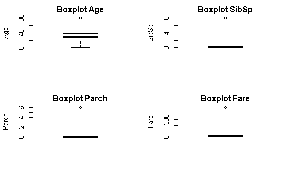

```r
# Boxplot
par(mfrow=c(2,2))
aed.trn$previsao = NULL
aed.trn$index = NULL
for(i in 1:ncol(aed.trn)){
    if(is.numeric(aed.trn[,i])){
        boxplot(summary(aed.trn[,i]),
                ylab = names(aed.trn)[i],
                main = paste("Boxplot", names(aed.trn)[i]))
    }
}
```

### 5.2.4 Medidas de Dispersão

As medidas de dispersão são a amplitude total, a variância, o desvio-padrão e o coeficiente de variação.

> **Amplitude Total**

É a diferença entre o maior e menor dos valores da série. A utilização da amplitude total como medida de dispersão é muito limitada, pois é uma medida que depende apenas dos valores extremos, não sendo afetada pela variabilidade interna dos valores da série.

```r
# Amplitude Total
for(i in 1:ncol(aed.trn)){
      amp <- diff(range(aed.trn[,i]))
      print(amp)
    }
}
```

[output not shown]

> **Variância**

```
A variância é a medida de dispersão mais empregada geralmente, pois leva em consideração a totalidade dos valores da variável em estudo. Baseia-se nos desvios em torno da média aritmética, sendo um indicador de variabilidade.

Para medir o grau de variabilidade dos valores em torno da média, nada mais interessante do que estudarmos o comportamento dos desvios de cada valor individual da série em relação à média.

Queremos calcular a média dos desvios, porém sua soma pode ser nula. Como solução a esse problema a variância considera o quadrado de cada desvio evitando com isso que o somatório seja nulo.
```

```r
# Variância
for(i in 1:ncol(aed.trn)){
    if(is.numeric(aed.trn[,i])){
        print(
            var(aed.trn[,i])
            )
    }
}
```

```
[1] 203,8771
[1] 1,216043
[1] 0,6497282
[1] 2469,437
```

> **Desvio Padrão**

```
Seguindo a mesma linha de raciocínio usado para o cálculo da variância, necessitamos, agora, aproximar a medida de dispersão da variável original. Para isso, calculamos o desvio padrão, que é a raiz quadrada da variância.

Podemos representar o desvio padrão por uma distribuição normal:

- 68,26% das ocorrências se concentrarão na área do gráfico demarcada por um
desvio padrão à direita e um desvio padrão à esquerda da linha média;

- 95,44% das ocorrências estão a dois desvios padrão, para a direita e a esquerda da média e, finalmente;

- 99,72% das ocorrências ocorrem a três desvios padrão ao redor da média aritmética.
```

```r
# Desvio Padrão
for(i in 1:ncol(aed.trn)){
    if(is.numeric(aed.trn[,i])){
        print(
            sd(aed.trn[,i])
        )
    }
}
```

```
[1] 14,27856
[1] 1,102743
[1] 0,8060572
[1] 49,69343
```

- **Coeficiente de Variação**

  Trata-se de uma medida relativa de dispersão, útil para a comparação em termos relativos do grau de concentração em torno da média de séries distintas.

  A importância de se estudar o coeficiente de variação se dá, pois o desvio-padrão é relativo à média. E como duas distribuições podem ter médias diferentes, o desvio destas distribuições não é comparável. Logo, o coeficiente de variação é muito utilizado para comparação entre amostras.

```r
# Coeficiente de Variação
for(i in 1:ncol(aed.trn)){
    if(is.numeric(aed.trn[,i])){
        cv <- 100*sd(aed.trn[,i]/mean(aed.trn[,i]))
        print(cv)
    }
}
```

```
[1] 48,37212
[1] 210,8464
[1] 211,2344
[1] 154,3073
```

### 5.2.5 Medidas de Assimetria e Achatamento

- Assimetria

  Duas distribuições podem se diferenciar uma da outra em termos de assimetria ou achatamento, ou de ambas. A assimetria e o achatamento têm importância devido a hipótese de que populações são distribuídas normalmente.

  A assimetria de Pearson, é baseada nas relações entre a média, mediana e moda. Essas três medidas são idênticas em valor para uma distribuição unimodas simétria, mas, para uma distribuição assimétrica, a média distancia-se da moda situando-se a mediana em uma posição intermediária, à medida que aumenta a assimetria da distribuição.

  Consequentemente, a distância entre a média e a moda poderia ser usada para medir a assimetria.
- Achatamento

  Curtose é o grau de achatamento em uma distribuição de frequência que têm apenas uma moda, ou seja, uma unimodal, em relação à normal. Mede o agrupamento de valores em torno do centro. Quanto maior esse agrupamento, maior será o valor da curtose.

  Os tipos de curtose são:
  - Leptocúrtica
  - Mesocúrtica
  - Platicúrtica

  A curtose analisa a curva de frequência de forma vertical, relacionando a sua característica com a característica de uma distribuição normal.

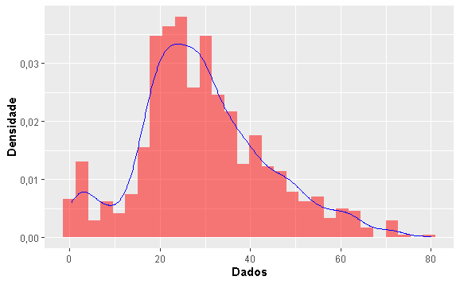

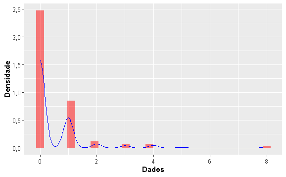

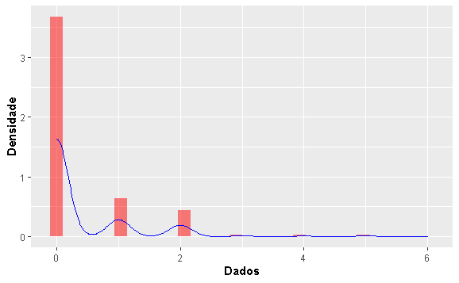

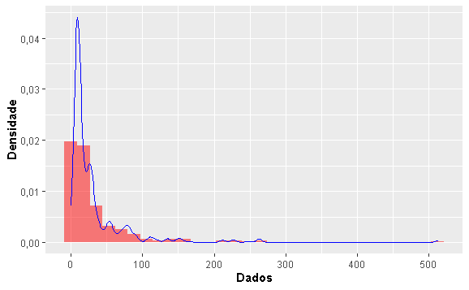

```r
par(mfrow=c(2,2))
for(i in 1:ncol(aed.trn)){
    if(is.numeric(aed.trn[,i])){

        datasim <- data.frame(aed.trn[,i])
        g <- ggplot(datasim, aes(x = aed.trn[,i]), binwidth = 2) +
          geom_histogram(aes(y = ..density..), fill = 'red', alpha = 0.5) +
          geom_density(colour = 'blue') + xlab(expression(bold('Dados'))) +
          ylab(expression(bold('Densidade')))

        print(g)

    }
}
```

```r
# Coeficiente de Assimetria (Skew)
for(i in 1:ncol(aed.trn)){
    if(is.numeric(aed.trn[,i])){
        ca <- skewness(aed.trn[,i])
        print(ca)
    }
}
```

```
[1] 0,4551571
[1] 3,682919
[1] 2,739868
[1] 4,77121
```

```r
# Coeficiente de Curtose
for(i in 1:ncol(aed.trn)){
    if(is.numeric(aed.trn[,i])){
        ck <- kurtosis(aed.trn[,i])
        print(ck)
    }
}
```

```
[1] 0,2972821
[1] 17,72691
[1] 9,688085
[1] 33,12307
```

## 5.3 Análise Bivariada

O objetivo principal das análises nessa situação é *explorar relações* (similaridades) *entre as colunas*, ou algumas vezes *entre as linhas* através da *distribuição conjunta das frequências*.

Em algumas situações, podem ter dois ou mais conjuntos de dados provenientes da observação da mesma variável.

- Quando se considera duas variáveis ou dois conjuntos de dados, existem três situações:
  - As duas variáveis são qualitativas;
  - As duas variáveis são quantitativas; e
  - Uma variável é qualitativa e a outra é quantitativa.

### 5.3.1 Duas Categóricas

Quando as variáveis são qualitativas, os dados são resumidos em *tabelas de dupla entrada* (ou de *contingência*), onde aparecerão as frequências absolutas. Pode-se ainda, adicionar o total por linha e o total por coluna. As distribuições assim obtidas são chamadas tecnicamente de *distribuições marginais*.

Em vez de se trabalhar com frequências absolutas, constrói-se tabelas com frequências relativas. Porém, existem três possibilidades de se expressar as frequências relativas de cada casela (célula):

1. Em relação ao total geral;
2. Em relação ao total de cada linha; e,
3. Em relação ao total de cada coluna.

#### 5.3.1.1 Tabelas de Contingência

A função *CrossTable* implementa uma tabela de tabulação cruzada, com testes de qui-quadrado, Fisher e McNemar de independência de todos os fatores da tabela. Seu resultado já apresenta as três possibilidades de frequências relativas.

*Qui Quadrado* é um teste de hipótese que encontra um *valor de dispersão para duas variáveis nominais*. Compara proporções, divergências entre frequências observadas e esperadas para um certo evento.

```r
par(mfrow=c(1,2))
for(i in var.fct[-1]){
  CrossTable(aed.trn$Survived,
             aed.trn[,i],
             prop.t = T,
             chisq = T,
             digits = 2,
             dnn = c("Survived", i))
  }
```

```
   Cell Contents
|-------------------------|
|                       N |
| Chi-square contribution |
|           N / Row Total |
|           N / Col Total |
|         N / Table Total |
|-------------------------|


Total Observations in Table:  891


             | Sex
    Survived |     Homem |    Mulher | Row Total |
-------------|-----------|-----------|-----------|
         Não |        81 |       468 |       549 |
             |     65,39 |     35,58 |           |
             |      0,15 |      0,85 |      0,62 |
             |      0,26 |      0,81 |           |
             |      0,09 |      0,53 |           |
-------------|-----------|-----------|-----------|
         Sim |       233 |       109 |       342 |
             |    104,96 |     57,12 |           |
             |      0,68 |      0,32 |      0,38 |
             |      0,74 |      0,19 |           |
             |      0,26 |      0,12 |           |
-------------|-----------|-----------|-----------|
Column Total |       314 |       577 |       891 |
             |      0,35 |      0,65 |           |
-------------|-----------|-----------|-----------|


Statistics for All Table Factors


Pearson's Chi-squared test
------------------------------------------------------------
Chi^2 =  263,0506     d.f. =  1     p =  3,711748e-59

Pearson's Chi-squared test with Yates' continuity correction
------------------------------------------------------------
Chi^2 =  260,717     d.f. =  1     p =  1,197357e-58
```

```
Chi-squared approximation may be incorrect
```

```
   Cell Contents
|-------------------------|
|                       N |
| Chi-square contribution |
|           N / Row Total |
|           N / Col Total |
|         N / Table Total |
|-------------------------|


Total Observations in Table:  891


             | Embarked
    Survived |          -  |   Cherbourg |  Queenstown | Southampton |   Row Total |
-------------|-------------|-------------|-------------|-------------|-------------|
         Não |           0 |          75 |          47 |         427 |         549 |
             |        1,23 |        7,86 |        0,00 |        2,30 |             |
             |        0,00 |        0,14 |        0,09 |        0,78 |        0,62 |
             |        0,00 |        0,45 |        0,61 |        0,66 |             |
             |        0,00 |        0,08 |        0,05 |        0,48 |             |
-------------|-------------|-------------|-------------|-------------|-------------|
         Sim |           2 |          93 |          30 |         217 |         342 |
             |        1,98 |       12,61 |        0,01 |        3,69 |             |
             |        0,01 |        0,27 |        0,09 |        0,63 |        0,38 |
             |        1,00 |        0,55 |        0,39 |        0,34 |             |
             |        0,00 |        0,10 |        0,03 |        0,24 |             |
-------------|-------------|-------------|-------------|-------------|-------------|
Column Total |           2 |         168 |          77 |         644 |         891 |
             |        0,00 |        0,19 |        0,09 |        0,72 |             |
-------------|-------------|-------------|-------------|-------------|-------------|


Statistics for All Table Factors


Pearson's Chi-squared test
------------------------------------------------------------
Chi^2 =  29,67061     d.f. =  3     p =  1,618719e-06
```

### 5.3.2 Duas Numéricas

É útil identificar se existe uma *associação linear* entre duas variáveis ou entre mais de duas variáveis e, se apropriado, *quantificar a associação*.

Um dispositivo bastante útil para se verificar a *associação* entre duas variáveis quantitativas, ou entre dois conjuntos de dados, é o *diagrama de dispersão*.

Sua associação pode ser *quantificada* utilizando-se uma medida estatística chamada *coeficiente de correlação* ou *grau de associação*.

#### 5.3.2.1 Diagramas de Dispersão

A *relação* entre as variáveis pode ser *fortemente linear*, *não linear* ou mesmo *inexistente*. Portanto, um diagrama de dispersão *é uma primeira indicação* útil da possível existência *de uma associação entre duas variáveis*.

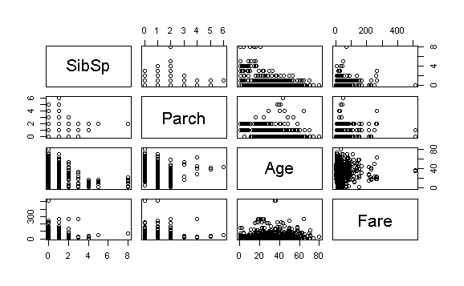

```r
# Diagramas de Dispersão - Matriz de Correlação
plot(aed.trn[,c(var.num, var.num_con)])
```

#### 5.3.2.2 Coeficiente de Correlação

Mede a *força* de associação entre duas variáveis. Essa medição leva em consideração a dispersão entre os valores dados. Quanto menos dispersos estiverem os dados, mais forte será a dependência, isto é, a associação entre as variáveis.

O coeficiente de correlação “R” assume um valor entre [– 1 e + 1], isto é:

- Se r = 1, a correlação é positiva perfeita;
- Se r = -1, a correlação é negativa perfeita;
- Se r = 0, a correlação é nula.

```r
# Tabela dos Coeficientes de Correlação
cor(aed.trn[,c(var.num, var.num_con)])
```

```
           SibSp      Parch         Age       Fare
SibSp  1,0000000  0,4148377 -0,30545660 0,15965104
Parch  0,4148377  1,0000000 -0,20240051 0,21622494
Age   -0,3054566 -0,2024005  1,00000000 0,09312934
Fare   0,1596510  0,2162249  0,09312934 1,00000000
```

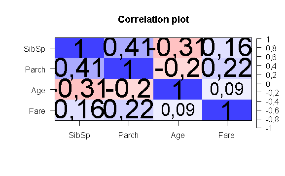

```r
# Gráfico dos Coeficientes de Correlação
cor.plot(aed.trn[,c(var.num, var.num_con)])
```

#### 5.3.2.3 Covariância

```r
cov(aed.trn[,c(var.num, var.num_con)])
```

```
           SibSp      Parch        Age        Fare
SibSp  1,2160431  0,3687386  -4,809592    8,748734
Parch  0,3687386  0,6497282  -2,329495    8,661052
Age   -4,8095922 -2,3294948 203,877136   66,079957
Fare   8,7487338  8,6610517  66,079957 2469,436846
```

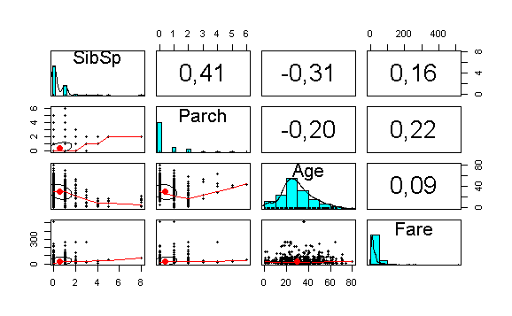

```r
# Diagramas de Dispersão + Coeficientes de Correlação
pairs.panels(aed.trn[,c(var.num, var.num_con)])
```

### 5.3.3 Uma Númerica e outra Categórica

Em geral *analisa-se o que acontece com a variável quantitativa dentro de cada categoria da variável qualitativa.*. Essa análise pode ser conduzida por meio de *medidas-resumo* ou *box plot*.

As medidas-resumo são agrupadas por categoria da variável qualitativa. A partir daí, constroem-se boxplots baseados em cada medida-resumo. Então, os boxplots são comparados visualmente.

#### 5.3.3.1 Medidas-resumo

*As medidas-resumo são calculadas para a variável quantitativa, a variável que se quer observar o comportamento.*

#### 5.3.3.2 Boxplot

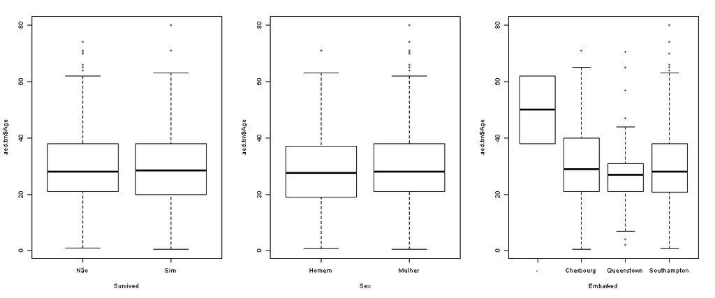

```r
# Boxplots Idade conforme as Categóricas
par(mfrow=c(1,3), cex = 0.65)
for(i in var.fct){
  boxplot(aed.trn$Age ~ aed.trn[,i], beside = TRUE, xlab = names(aed.trn)[grep(i, names(aed.trn))])
}
```

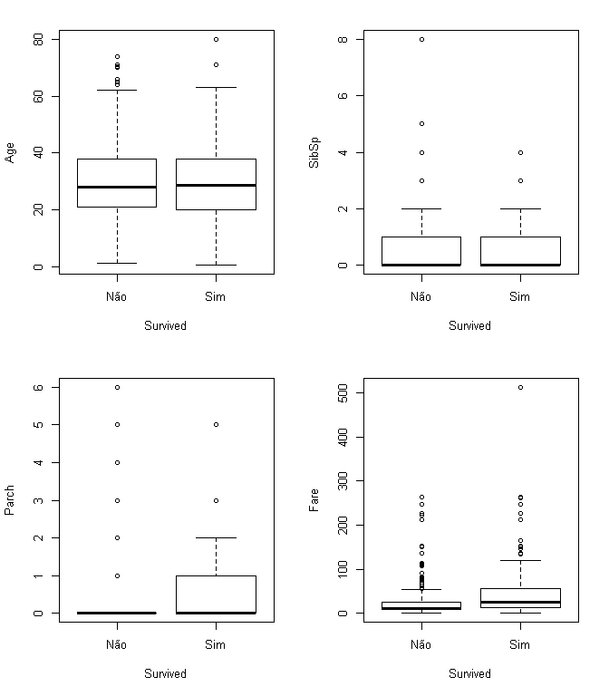

```r
# Boxplots Numéricas conforme as Survived
par(mfrow=c(2,2))
for(i in 0:length(aed.trn)){
  if(is.numeric(aed.trn[,i])){
    boxplot(aed.trn[,i] ~ Survived, ylab = names(aed.trn)[i], data = aed.trn)
  }
}
```

- Intervalo Interquartil (IQ): Diferença entre o 3º e o 1º quartil. O comprimento do lado vertical.
- Limite Inferior (LI): *Q1 - 1,5IQ*
- Limite Superior (LS): *Q3 + 1,5IQ*
- Outliers: Um dado será considerado outlier se ele for *menor que o* *LI* ou *maior que o* *LS*.
  - O que fazer com os outliers:
    1. Excluir - valores absurdos, p.ex. idade de 180 anos;
    2. Buscar possíveis causas;
    3. Verificar diferenças na análise com e sem o outlier;
    4. Categorizar a variável, p.ex. o outlier entraria em valores maiores que x.
- Informações que podem ser retiradas:
  1. Número de outliers;
  2. Valor mediano aproximado;
  3. Intervalo onde estão 50% dos valores;
  4. Simetria da variável baseada na distância dos quartis até a mediana.

```r
dput(aed.trn, file = "datasets/aed_trn.R")
```

# 6 Pré-Processamento

## 6.1 Escala e Normalização

Como o intervalo de valores dos dados brutos varia muito, em alguns algoritmos de aprendizado de máquina, as funções objetivas não funcionarão corretamente sem normalização. Outra razão pela qual o dimensionamento de recursos é aplicado é que a [descida do gradiente](https://en.wikipedia.org/wiki/Gradient_descent) converge muito mais rapidamente com o dimensionamento de recursos do que sem ele.

- Métodos: *[Feature Scaling](https://en.wikipedia.org/wiki/Feature_scaling)*
  5. **Re-escalonar (Normalização Min-Max):** é o método mais simples e consiste em redimensionar o intervalo de recursos para dimensionar o intervalo em [0, 1] ou [-1, 1].
  6. **Escore-Z (Padronização):** No aprendizado de máquina, podemos lidar com vários tipos de dados, por exemplo, sinais de áudio e valores de pixel para dados de imagem, e esses dados podem incluir várias dimensões. A padronização de recursos faz com que os valores de cada recurso nos dados tenham média zero (ao subtrair a média no numerador) e variação de unidade. Esse método é amplamente utilizado para normalização em muitos algoritmos de aprendizado de máquina (por exemplo, máquinas de vetores de suporte, regressão logística e redes neurais artificiais). O método geral de cálculo é determinar a média de distribuição e o desvio padrão para cada recurso. Em seguida, subtraímos a média de cada recurso. Em seguida, dividimos os valores (a média já está subtraída) de cada recurso pelo seu desvio padrão.

### 6.1.1 Normalização (Min-Max)

### 6.1.2 Padronização (Z-Score)

```r
z.trn <- dget(file = "datasets/aed_trn.R")
# Padroniza
z.trn[c(var.num, var.num_con)] <- sapply(z.trn[c(var.num, var.num_con)], scale)
z.tst <- dget(file = "datasets/etl_tst.R")
# Padroniza
z.tst[c(var.num, var.num_con)] <- sapply(z.tst[c(var.num, var.num_con)], scale)
```

```r
# Exporta
dput(z.trn, file = "datasets/z_trn.R")
dput(z.tst, file = "datasets/z_tst.R")
```

```r
stargazer(aed.trn, type = "text")
```

```
============================================================================
Statistic  N     Mean      St. Dev.    Min  Pctl(25)  Pctl(75)      Max
----------------------------------------------------------------------------
Age       891 29,,518.000 14,,279.000   0      21        38         80
SibSp     891 0,,523.000  1,,103.000    0       0        1           8
Parch     891 0,,382.000  0,,806.000    0       0        0           6
Fare      891 32,,204.000 49,,693.000 0.000 7,,91.000  31.000  5,12,,329.000
----------------------------------------------------------------------------
```

```r
stargazer(z.trn, type = "text")
```

```
============================================================================
Statistic  N   Mean  St. Dev.     Min      Pctl(25)    Pctl(75)      Max
----------------------------------------------------------------------------
Age       891 -0.000  1.000   -2,,038.000 -0,,597.000 0,,594.000  3,,536.000
SibSp     891 0.000   1.000   -0,,474.000 -0,,474.000 0,,433.000  6,,78.000
Parch     891 0.000   1.000   -0,,473.000 -0,,473.000 -0,,473.000 6,,97.000
Fare      891 -0.000  1.000   -0,,648.000 -0,,489.000 -0,,024.000 9,,662.000
----------------------------------------------------------------------------
```

## 6.2 Feature Selection

# 7 Modelagem

```r
massa <- z.trn
mdl.tst <- z.tst
```

## 7.1 Amostragem

> **Dividir os dados em Treinamento, Validação e Teste.**
- *Conjunto de dados de treinamento:* a amostra de dados usada para ajustar o modelo.
- *Conjunto de dados de validação:* é usado para avaliar um determinado modelo. Usamos esses dados para ajustar os hiperparâmetros do modelo. Portanto, o modelo ocasionalmente vê esses dados, mas nunca “aprende” com eles. Nós usamos os resultados do conjunto de validação e atualizamos os hiperparâmetros de nível superior. Portanto, a validação definida de uma maneira afeta um modelo, mas indiretamente.
- *Conjunto de dados de teste:* a amostra de dados usada para fornecer uma avaliação imparcial de um ajuste final do modelo no conjunto de dados de treinamento. Só é usado quando um modelo é completamente treinado (usando os conjuntos de treino e validação). O conjunto de testes geralmente é o que é usado para avaliar modelos concorrentes (por exemplo, em muitas competições Kaggle, o conjunto de validação é lançado inicialmente juntamente com o conjunto de treinamento e o conjunto de testes real é lançado somente quando a competição está prestes a fechar e é o resultado do modelo no conjunto de teste que decide o vencedor). Muitas vezes, o conjunto de validação é usado como o conjunto de teste, mas não é uma boa prática. O conjunto de testes geralmente é bem organizado. Ele contém dados cuidadosamente amostrados que abrangem as várias classes que o modelo enfrentaria, quando usado no mundo real.

> *Nota sobre validação cruzada:* *Muitas vezes, as pessoas primeiro dividem seus conjuntos de dados em 2 - Treinar e Testar. Depois disso, eles deixam de lado o conjunto de testes e escolhem aleatoriamente X% do conjunto de dados de trem para ser o conjunto de trens real e o restante (100-X)% para o conjunto de validação , onde X é um número fixo (por exemplo, 80% ), o modelo é treinado e validado iterativamente nesses diferentes conjuntos. Existem várias maneiras de fazer isso e é comumente conhecido como Validação Cruzada. Basicamente, você usa seu conjunto de treinamento para gerar várias divisões dos conjuntos de treinamento e validação. A validação cruzada evita o ajuste e está se tornando cada vez mais popular, com a Validação Cruzada K-fold sendo o método mais popular de validação cruzada.*

**Fontes:**

1. *https://towardsdatascience.com/train-validation-and-test-sets-72cb40cba9e7*
2. *https://machinelearningmastery.com/difference-test-validation-datasets/*

> *Resampling*

A semente é um número criado a partir do horário atual e do ID do processo, para garantir a aleatoriedade dos resultados. Fixá-lo permite que esses resultados sejam reproduzíveis.

```r
# Configurando uma semente para que o Gerador Aleatório de Números seja reproduzível.
set.seed(1618)
# Criando uma coluna com índices randômicos.
massa[ ,'index'] <- ifelse(runif(nrow(massa)) < 0.8, 1, 0)
# Criando os conjuntos de treino e de validação.
mdl.trn <- massa[massa$index == 1, ]
mdl.vld <- massa[massa$index == 0, ]
# Obtem o índice (posição), no vetor de nomes, onde corresponde ao valor 'index'.
col_idx <- grep('index', names(mdl.trn))
# Remove a coluna 'index' dos datasets, utilizando a posição obtida.
mdl.trn <- mdl.trn[ , -col_idx]
mdl.vld <- mdl.vld[ , -col_idx]
```

## 7.2 Treino

> Treinando um *Modelo Linear Generalizado* para classificação.

```r
# Gerar Modelos de Classificação
ajt.trn <- glm(formula = Survived ~
                 Pclass +
                 Sex +
                 Age +
                 SibSp +
                 Parch +
                 Fare +
                 Embarked,
               family = binomial(link = "logit"),
               data = mdl.trn)
```

**Resumo do modelo treinado:**

```r
summary(ajt.trn)
```

```
Call:
glm(formula = Survived ~ Pclass + Sex + Age + SibSp + Parch +
    Fare + Embarked, family = binomial(link = "logit"), data = mdl.trn)

Deviance Residuals:
    Min       1Q   Median       3Q      Max
-2,4302  -0,5909  -0,3804   0,5773   2,5459

Coefficients:
                     Estimate Std. Error z value Pr(>|z|)
(Intercept)          13,80006  617,35844   0,022 0,982166
Pclass.L             -1,67447    0,24396  -6,864 6,71e-12 ***
Pclass.Q             -0,09544    0,20750  -0,460 0,645554
SexMulher            -2,76114    0,22499 -12,272  < 2e-16 ***
Age                  -0,39993    0,11923  -3,354 0,000796 ***
SibSp                -0,31971    0,12852  -2,488 0,012860 *
Parch                -0,09996    0,11523  -0,867 0,385678
Fare                  0,03026    0,13836   0,219 0,826861
EmbarkedCherbourg   -11,97988  617,35849  -0,019 0,984518
EmbarkedQueenstown  -11,95486  617,35855  -0,019 0,984550
EmbarkedSouthampton -12,55022  617,35848  -0,020 0,983781
---
Signif. codes:  0 ‘***’ 0,001 ‘**’ 0,01 ‘*’ 0,05 ‘.’ 0,1 ‘ ’ 1

(Dispersion parameter for binomial family taken to be 1)

    Null deviance: 969,78  on 734  degrees of freedom
Residual deviance: 631,98  on 724  degrees of freedom
AIC: 653,98

Number of Fisher Scoring iterations: 13
```

## 7.3 Validação

> Validando o modelo através de predições utilizando o *Conjunto de Validação*.

```r
pred <- predict( ajt.trn,
                     newdata = mdl.vld,
                     type = "response" )
# Criando um dataframe com os dados observados e os preditos.
previsoes <- data.frame(observado = mdl.vld$Survived,
                        previsto = pred %>%
                                      round() %>%
                                      factor(labels = c("Não", "Sim")))
```

```r
CrossTable(previsoes$observado,
           previsoes$previsto)
```

```
   Cell Contents
|-------------------------|
|                       N |
| Chi-square contribution |
|           N / Row Total |
|           N / Col Total |
|         N / Table Total |
|-------------------------|


Total Observations in Table:  156


                    | previsoes$previsto
previsoes$observado |       Não |       Sim | Row Total |
--------------------|-----------|-----------|-----------|
                Não |        82 |         5 |        87 |
                    |     7,868 |    17,703 |           |
                    |     0,943 |     0,057 |     0,558 |
                    |     0,759 |     0,104 |           |
                    |     0,526 |     0,032 |           |
--------------------|-----------|-----------|-----------|
                Sim |        26 |        43 |        69 |
                    |     9,921 |    22,321 |           |
                    |     0,377 |     0,623 |     0,442 |
                    |     0,241 |     0,896 |           |
                    |     0,167 |     0,276 |           |
--------------------|-----------|-----------|-----------|
       Column Total |       108 |        48 |       156 |
                    |     0,692 |     0,308 |           |
--------------------|-----------|-----------|-----------|
```

```r
chisq.test(previsoes$observado,
           previsoes$previsto)
```

```
    Pearson's Chi-squared test with Yates' continuity correction

data:  previsoes$observado and previsoes$previsto
X-squared = 55,188, df = 1, p-value = 1,095e-13
```

[figure not shown]

### 7.3.1 Avaliação

Para avaliar o desempenho do modelo nos dados de validação, foi construída uma *matriz de confusão*.

```r
cm <- confusionMatrix(previsoes$observado,
                      previsoes$previsto,
                      positive = "Sim")
```

Matriz de Confusão - Usando o pacote Caret

```r
print(cm)
```

```
Confusion Matrix and Statistics

          Reference
Prediction Não Sim
       Não  82   5
       Sim  26  43

               Accuracy : 0,8013
                 95% CI : (0,73, 0,8608)
    No Information Rate : 0,6923
    P-Value [Acc > NIR] : 0,001518

                  Kappa : 0,5841

 Mcnemar's Test P-Value : 0,000328

            Sensitivity : 0,8958
            Specificity : 0,7593
         Pos Pred Value : 0,6232
         Neg Pred Value : 0,9425
             Prevalence : 0,3077
         Detection Rate : 0,2756
   Detection Prevalence : 0,4423
      Balanced Accuracy : 0,8275

       'Positive' Class : Sim
```

Accuracy

“Através da *Matriz de Confusão* obtivemos a Acurácia de *80,13%*, ela corresponde a fração das premissas corretas em relação ao total de observações. Esta métrica também poderia ser calculada utilizando a função *table()* ou a função *CrossTable()*, pois ela corresponde a soma das predições corretas dividida pelo total de observações.  
Porém, não é suficiente (e nem segura) para avaliarmos a eficiência do modelo. Analisamos então, outras métricas obtidas pela Confusion Matrix, que nos informe não apenas o percentual de acertos, mas também a precisão e a sensibilidade.”

*95% CI*

O *Intervalo de Confiança*, denotado por *95% CI*, é *[0,73, 0,8608]*. Ele é uma *estimativa por intervalo* de um *parâmetro populacional*, que com dada frequência (*Nível de Confiança*), inclui o parâmetro de interesse. Nesse caso específico, significa dizer que 95% dos *intervalos de confiança* observados têm o valor real do parâmetro.

*No Information Rate*

*P-Value [Acc > NIR]*

*Kappa*

O *Teste de Concordância Kappa* foi igual a *0,5841*. O coeficiente de Kappa tem a finalidade de medir o grau de concordância entre proporções. Ele demonstra se uma dada classificação pode ser considerada confiável.

Mcnemar’s Test P-Value

Sensitivity

Specificity

Pos Pred Value

Neg Pred Value

Prevalence

Detection Rate

Detection Prevalence

Balanced Accuracy

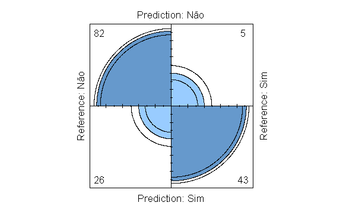

```r
fourfoldplot(cm$table)
```

O pacote Caret nos dá, já calculadas, as principais métricas estatísticas, baseadas nos tipos de acertos e, nos tipos de erros. Para a *Acurácia*, não havia diferenças, apenas acertos e erros.

Agora, os erros são classificados como *“Erro do Tipo I”* e *“Erro do Tipo II”*. O primeiro é *baseado nos* *Falsos Positivos (FP)*, o segundo é *baseado nos* *Falsos Negativos (FN)*.

Normalmente, ao se testar uma hipótese, é definido o *nível de significância* do *Erro do Tipo I*, chamado de α, tipicamente de 5%. Ou seja, com α = 0,05, existe 5% de chance de se rejeitar a hipótese nula, no caso dela ser verdadeira.  
- Ao se diminuir a probabilidade de ocorrer um *Erro do Tipo I*, ou seja, diminuindo o valor de α, aumenta-se a probabilidade de se ocorrer um *Erro do Tipo II*. A probabilidade da ocorrência do Erro do tipo II é chamada de β.

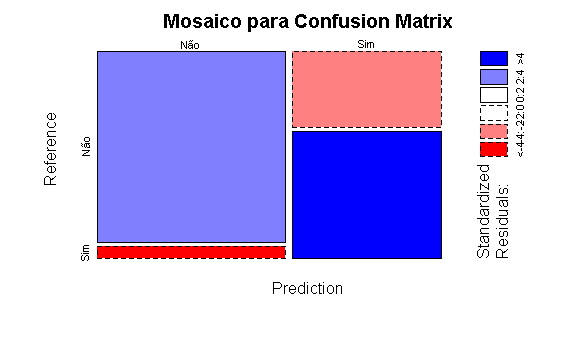

```r
mosaicplot(cm$table, color = TRUE, shade = TRUE, main = "Mosaico para Confusion Matrix", )
```

A partir destas definições construímos as duas principais métricas, a *Precisão* e a *Sensibilidade*.

A **Precisão** demonstra que de todos os casos previstos como **TP**, quantos realmente estavam certos.  
A **Sensibilidade** mostra que de todos os possíveis casos onde o target era 1, quanto o modelo conseguiu capturar.

Se *diminuírmos o erro do tipo I* (FP), tornaremos nosso modelo *mais preciso*.  
Se *diminuírmos o erro do tipo II* (FN), tornaremos o modelo *mais sensível*.

Para alterarmos esses valores, devemos analizar as predições como uma distribuição de probabilidade, encontrando a probabilidade de cada observação pertencer a classe 1 ou 0.

O *Threshold* é o percentual que definirá essa escolha, o corte que separará as classes.

A *F1-Score* é uma alternativa para não utilizarmos a Precisão e a Sensibilidade. Ela é uma média harmônica entre essas duas, o que torna a métrica mais sensível a desproporções.

Outra forma é a *F-Beta* onde podemos escolher o Peso entre Precisão e Sensibilidade através do parâmetro Beta.

#### 7.3.1.1 Métricas de Avaliação

Avaliar um modelo de Classificação Binária:

*Acurácia (Accuracy)*, *Precisão (Precision)*, *Sensibilidade (Recall)* e *Pontuação F1 (F1-Score)*.

```r
acuracia <- (cm$table[1,1] + cm$table[2,2])/(cm$table[1,1] + cm$table[1,2] + cm$table[2,1] + cm$table[2,2])
```

```r
# Precision
precisao <- cm$table[1,1] / (cm$table[1,1] + cm$table[1,2])
```

```r
sensibilidade <- cm$table[1,1] / (cm$table[1,1] + cm$table[2,1])
```

```r
f1 <- (2 * sensibilidade * precisao) / (sensibilidade + precisao)
```

```r
metricas <- kable(
              data.frame(
                "Acuracia" = acuracia,
                "Precisao" = precisao,
                "Sensibilidade" = sensibilidade,
                "F1-Score" = f1), format = "markdown", align = 'l')
metricas
```

| Acuracia | Precisao | Sensibilidade | F1.Score |
| --- | --- | --- | --- |
| 0,8012821 | 0,9425287 | 0,7592593 | 0,8410256 |

#### 7.3.1.2 Curva ROC

```r
class1 <- predict(ajt.trn, newdata = mdl.vld, type = "response")
class2 <- mdl.vld$Survived
pred <- prediction(class1, class2)
perf <- performance(pred, "tpr", "fpr")
```

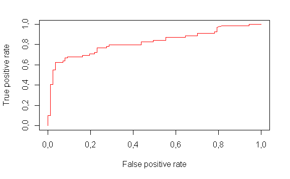

```r
# Gerando uma curva ROC em R
plot(perf, col = rainbow(10, alpha = NULL))
```

Realizando o *Teste Chi-Quadrado* (X²).

```r
chisq.test(previsoes$observado, previsoes$previsto)
```

```
    Pearson's Chi-squared test with Yates' continuity correction

data:  previsoes$observado and previsoes$previsto
X-squared = 55,188, df = 1, p-value = 1,095e-13
```

## 7.4 Teste

Predição de teste utilizando novos dados.

```r
predict(ajt.trn,
        newdata = mdl.tst,
        type = "response") %>%
  round() %>%
  factor(labels = c("Não", "Sim")) -> predicao
```

Tabela para as predições de teste.

```r
CrossTable(predicao, prop.t = T, digits = 2)
```

```
   Cell Contents
|-------------------------|
|                       N |
|         N / Table Total |
|-------------------------|


Total Observations in Table:  418


          |       Não |       Sim |
          |-----------|-----------|
          |       267 |       151 |
          |      0,64 |      0,36 |
          |-----------|-----------|
```